# Homework_2

### Exercise 3

Sometimes it could be useful to asses the degree of association, or correlation, between paired samples, using the Pearson, the Kendall’s $\tau$ or the Spearman’s $\rho$ correlation coefficient. Regardless of the adopted cofficient, the null hypothesis for a given correlation coefficent $\rho$ is:

$$H_0: \rho = 0$$

The test statistic is then defined as

$$T = r \sqrt{\frac{n-2}{1-r^2}} \underset{H_0}{\sim} t_{n-2},$$

where $\mathrm{Corr}(X, Y)$ is the Pearson correlation coefficient. Suppose to have two samples of the same length $x_1, \ldots, x_n$, $y_1, \ldots, y_n$, and to measure the association between them. Once we compute the test statistic $t_\mathrm{obs}$, we may then compute the $p$-value (here we are evaluating a two sided test) as:

$$p = 2 Pr_{H_0}(T \geq |T_\mathrm{obs}|).$$

Consider now some of the most followed Instagram accounts in 2018: for each of the owners, we report also the number of Twitter followers (in milions). Are the Instagram and Twitter account somehow associated? Perform a correlation test, compute the $p$-value and give an answer. Here is the dataframe.

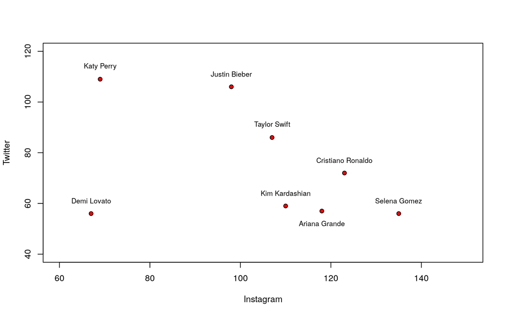

```r
Owners <- c( "Katy Perry", "Justin Bieber", "Taylor Swift", "Cristiano Ronaldo",
                   "Kim Kardashian", "Ariana Grande", "Selena Gomez", "Demi Lovato")
Instagram <- c( 69, 98,107, 123, 110, 118, 135, 67)
Twitter <- c( 109, 106, 86, 72, 59, 57, 56, 56)
plot( Instagram, Twitter, pch=21, bg=2, xlim=c(60, 150), ylim=c(40, 120) )
text( Instagram[-6], Twitter[-6]+5, Owners[-6], cex=0.8 )
text( Instagram[6], Twitter[6]-5, Owners[6], cex=0.8 )
```

**Solution.**

In order to perform the test, let’s calculate the $p$-value corresponding to the observations. This $p$-value will be calculated manually by using the Pearson’s correlation.

```r
#parameters and correlation
r <- cor(x=Instagram, y=Twitter, method = "pearson")
n <- length(Instagram)
alpha <- 0.05

#t statistic and p-value
t <- r*sqrt((n-2)/(1-r*r))
pvalue <- pt(t, df=n-2, lower.tail = TRUE)

pvalue
```

```
## [1] 0.1478334
```

The resulting $p$-value is greater than $0.05$, so null hypothesis, in this case $\rho=0$, should be accepted. It means that in terms of the test, there is no sufficient significance to assume any association between the number of followers on Twitter and Instagram. Note that it does not imply that this correlation does not exist, it simply establishes the fact that, according to the test, it cannot be confirmed that there exists any correlation, also if it is the case.

The situation can also be shown with a graph:

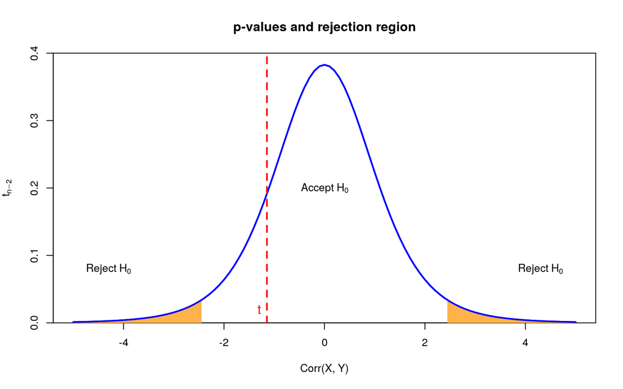

```r
#plot
library(RColorBrewer)
plotclr <- brewer.pal(6,"YlOrRd")
curve(dt(x,n-2),xlim=c(-5,5), ylim=c(0,0.4), main="p-values and rejection region",
      col = "blue", lwd = 2, xlab="Corr(X, Y)",  ylab=expression(t[n-2]),  yaxs="i")
cord.x_r <- c(qt(1-alpha/2,n-2),seq(qt(1-alpha/2,n-2), 5, 0.01), 5)
cord.y_r <- dt(cord.x_r, n-2); cord.y_r[1] <- 0; cord.y_r[length(cord.y_r)] <- 0
cord.x_l <- c(-5, seq(-5, qt(alpha/2,n-2), 0.01), qt(alpha/2,n-2))
cord.y_l <- dt(cord.x_l, n-2); cord.y_l[1] <- 0; cord.y_l[length(cord.y_l)] <- 0
polygon(cord.x_r,cord.y_r,col=plotclr[3], border = NA )
polygon(cord.x_l,cord.y_l,col=plotclr[3], border = NA )
curve(dt(x,n-2),xlim=c(-5,5),main=expression(t[n-2]), col = "blue", lwd = 2, add = TRUE, yaxs="i")
abline(v =t, lty=2, lwd=2, col="red")
text(0,0.2, expression(paste("Accept H"[0])))
text(4.3,0.08, expression(paste("Reject H"[0])))
text(-4.3,0.08, expression(paste("Reject H"[0])))
text(as.double(t)-0.15, 0.02, "t", col="red", cex=1.2)
```

As can be seen, the estimated statistic $T$ is within the acceptance region, as $p$-value indicates.

### Exercise 4

Compute analitically $J(\gamma, \gamma; y)$, $J(\gamma, \beta; y)$, $J(\beta, \beta; y)$.

**Solution.**

First of all, let’s recall the definition of the $J$ matrix. Given a certain model with likelihood $l(\theta; y)$ with data $y$ and parameters set $\theta$, $J(\theta; y)$ it is defined as follows:

$$J(\theta;y) = -\frac{\partial^2 l(\theta;y)}{\partial\theta \partial\theta^T}$$

Since $J$ matrix must be derived from the log-likelihood, let’s remember its expression:

$$l(\gamma,\beta;y) = n \log (\gamma) - n \gamma \log (\beta) + \gamma \sum_{i=1}^n \log(y_i) - \sum_{i=1}^n \left( \frac{y_i}{\beta} \right)^\gamma$$

Now it is possible to compute second-order derivatives:

1. $\partial_{\gamma\gamma}^2$ term:

$$\frac{\partial^2 l(\gamma,\beta;y)}{\partial\gamma^2} = -\frac{n}{\gamma^2} - \sum_{i=1}^n \left( \frac{y_i}{\beta} \right)^\gamma \log\left( \frac{y_i}{\beta} \right)^2$$

2. $\partial_{\gamma\beta}^2 = \partial_{\beta\gamma}^2$ term:

$$\begin{align*}
\frac{\partial^2 l(\gamma,\beta;y)}{\partial\gamma\partial\beta} &= - \frac{n}{\beta} - \left( -\frac 1\beta \right) \sum_{i=1}^n \left( \frac{y_i}{\beta} \right)^\gamma - \left( -\frac{\gamma}{\beta} \right) \sum_{i=1}^n \left( \frac{y_i}{\beta} \right)^\gamma \log \left( \frac{y_i}{\beta} \right) \\
&= - \frac{n}{\beta} + \frac 1\beta \sum_{i=1}^n \left( 1 + \gamma \log \left( \frac{y_i}{\beta} \right) \right) \left( \frac{y_i}{\beta} \right)^\gamma
\end{align*}$$

3. $\partial_{\beta\beta}^2$ term:

$$\begin{align*}
\frac{\partial^2 l(\gamma,\beta;y)}{\partial\beta^2} &= \frac{n\gamma}{\beta^2} - \frac{\gamma}{\beta^2} \sum_{i=1}^n \left( \frac{y_i}{\beta} \right)^\gamma - \frac{\gamma^2}{\beta^2} \sum_{i=1}^n \left( \frac{y_i}{\beta} \right)^\gamma \\
&= \frac{n\gamma}{\beta^2} - \frac{\gamma (\gamma + 1)}{\beta^2} \sum_{i=1}^n \left( \frac{y_i}{\beta} \right)^\gamma
\end{align*}$$

So we have that the elements of the $J$ matrix are:

$$\begin{align*}
J(\gamma, \gamma; y) &= -\frac{\partial^2 l(\gamma, \beta; y)}{\partial\gamma^2} = \frac{n}{\gamma^2} + \sum_{i=1}^n \left( \frac{y_i}{\beta} \right)^\gamma \log\left( \frac{y_i}{\beta} \right)^2 \\
J(\gamma, \beta; y) &= -\frac{\partial^2 l(\gamma,\beta;y)}{\partial\gamma\partial\beta} = \frac{n}{\beta} - \frac 1\beta \sum_{i=1}^n \left( 1 + \gamma \log \left( \frac{y_i}{\beta} \right) \right) \left( \frac{y_i}{\beta} \right)^\gamma \\
J(\beta, \beta; y) &= - \frac{\partial^2 l(\gamma,\beta;y)}{\partial\beta^2} = - \frac{n\gamma}{\beta^2} + \frac{\gamma (\gamma + 1)}{\beta^2} \sum_{i=1}^n \left( \frac{y_i}{\beta} \right)^\gamma
\end{align*}$$

### Exercise 5

Produce the contour plot for the quadratic approximation of the log-likelihood, based on the Taylor series:

$$\mathcal{l}(\theta) − \mathcal{l}(\widehat{\theta}) \approx - \frac12 (\theta - \widehat{\theta})^T J(\widehat{\theta})(\theta - \widehat{\theta}).$$

**Solution.**

We then have that

$$\mathcal{l}(\theta) \approx \mathcal{l}(\widehat{\theta}) - \frac12 (\theta - \widehat{\theta})^T J(\widehat{\theta})(\theta - \widehat{\theta}).$$

We write the log-likelihood function in $\texttt{R}$:

```r
log_lik_weibull <- function(data, param){
  sum(dweibull(data, shape = param[1], scale = param[2], log = TRUE))
}
```

Then we write the quadratic approximation of the log-likelihood function in $\texttt{R}$:

```r
qapprox_llweibull <- function(data, param, paramhat, Jhat){
  diff <- cbind(param[1] - paramhat[1], param[2] - paramhat[2])
  log_lik_weibull(data, paramhat) - 0.5 * diff %*% Jhat %*% t(diff)
}
```

Finally, we show the contour plot:

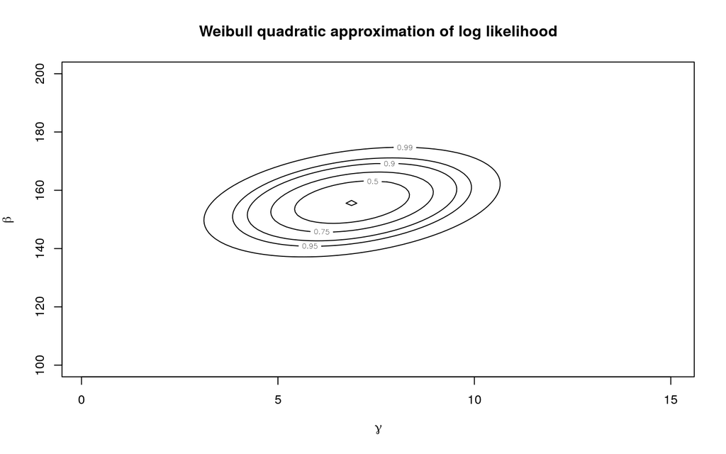

```r
y <- c(155.9, 200.2, 143.8, 150.1,152.1, 142.2, 147, 146, 146, 170.3, 148, 140, 118, 144, 97)
n <- length(y)

gammahat<-uniroot(function(x) n/x+sum(log(y))-n*sum(y^x*log(y))/sum(y^x), c(1e-5,15))$root
betahat<- mean(y^gammahat)^(1/gammahat)
weib.y.mle<-c(gammahat,betahat) #first element is the MLE for the shape gamma,
# while second element is the MLE for the scale beta

#observed information matrix
jhat<-matrix(NA,nrow=2,ncol=2)
jhat[1,1]<-n/gammahat^2+sum((y/betahat)^gammahat* (log(y/betahat))^2)
jhat[1,2]<-jhat[2,1]<- n/betahat-sum(y^gammahat/betahat^(gammahat+1)*(gammahat*log(y/betahat)+1))
jhat[2,2]<- -n*gammahat/betahat^2+gammahat*(gammahat+1) / betahat^(gammahat+2)*sum(y^gammahat)

#define parameters grid
gamma <- seq(0.1, 15, length=100)
beta <- seq(100,200, length=100)
parvalues <- expand.grid(gamma,beta)
appllikvalues <- apply(parvalues, 1, qapprox_llweibull, data=y,
                    paramhat=weib.y.mle, Jhat=jhat)
appllikvalues <- matrix(appllikvalues, nrow=length(gamma),
                     ncol=length(beta), byrow=F)
conf.levels <- c(0,0.5,0.75,0.9,0.95,0.99)

#contour plot
contour(gamma, beta, appllikvalues - max(appllikvalues),
    levels=-qchisq(conf.levels, 2)/2,
    xlab=expression(gamma),
    labels=as.character(conf.levels),
    ylab=expression(beta))
title('Weibull quadratic approximation of log likelihood')
```

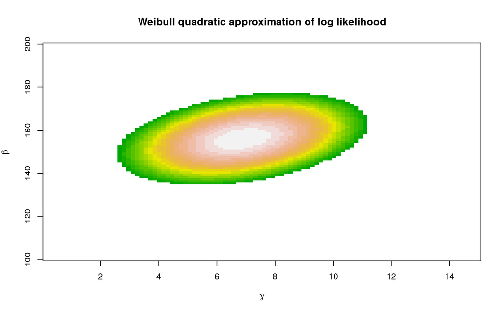

```r
#image
image(gamma, beta, appllikvalues - max(appllikvalues), zlim=c(-6,0),
    col=terrain.colors(20),xlab=expression(gamma),
    ylab=expression(beta))
title('Weibull quadratic approximation of log likelihood')
```